# Homework 5: Debugging and Testing

Statistical Computing, 36-350

Monday July 29, 2019

Name: David Yuan Andrew ID: dyuan1 Collaborated with: NA

On this homework, you can collaborate with your classmates, but you must identify their names above, and you must submit **your own** homework as an knitted HTML file on Canvas, by Monday August 5 at 10pm, next week.

# Introduction to percolation

In this homework, we’ll be coding a series of functions to investigate **percolation** via simulation. We’ll spend this section to discuss the problem and setup. You can read related literature on this topic at [Wikipedia](https://en.wikipedia.org/wiki/Percolation_theory), but we’ll be working with a simplified setting for this homework. As a word of caution, this is a coding heavy homework (as opposed to statistical), so be prepared to spend a lot of time debugging and testing.

Here’s the idea. Imagine you have a square board (10 by 10 squares) like the left board show below. This board consist of white “open” squares and black “blocked” squares. We are interested in knowing (abstractly) if we “pour water” from the top of the matrix, does the water “leak” from the bottom of the matrix. This is demonstrated in the right board. (Don’t worry, we’ll explain all the necessary specifics later.) You can think of this as the following: we indefinitely keep pouring water into each white square in the top row at the same time, and water runs through the board by spreading to any adjacent white square (left, right, top, and bottom). We keep pouring water until all the possibly-flooded squares are flooded. These are the blue squares shown below in the right board. Once we’re done, we see if the water reached any of the open squares in the bottom row of the board (i.e., are there any blue squares in the bottom row?). If so, we say the board “percolates”. Otherwise, it does not percolate. In the figure shown below, the displayed board percolates (left is the original board, and right is the percolated board).

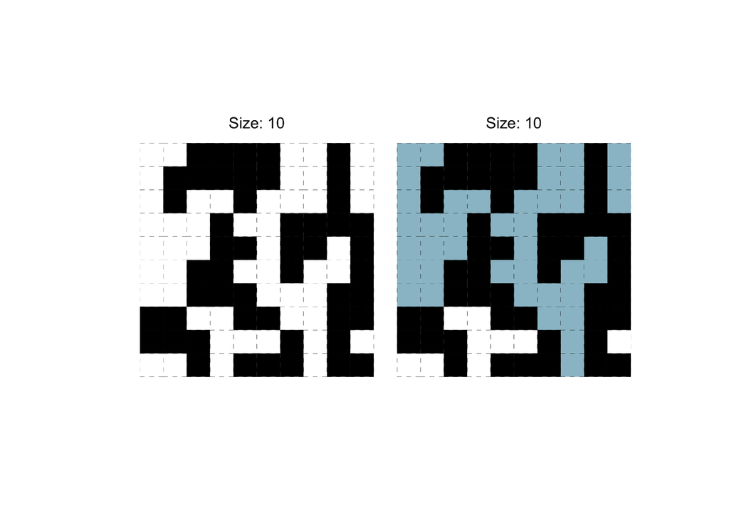

However, not all boards percolate. Consider the next board, shown below. Once again, we show the initial board on the left, and we start pouring water, resulting in the board on the right.

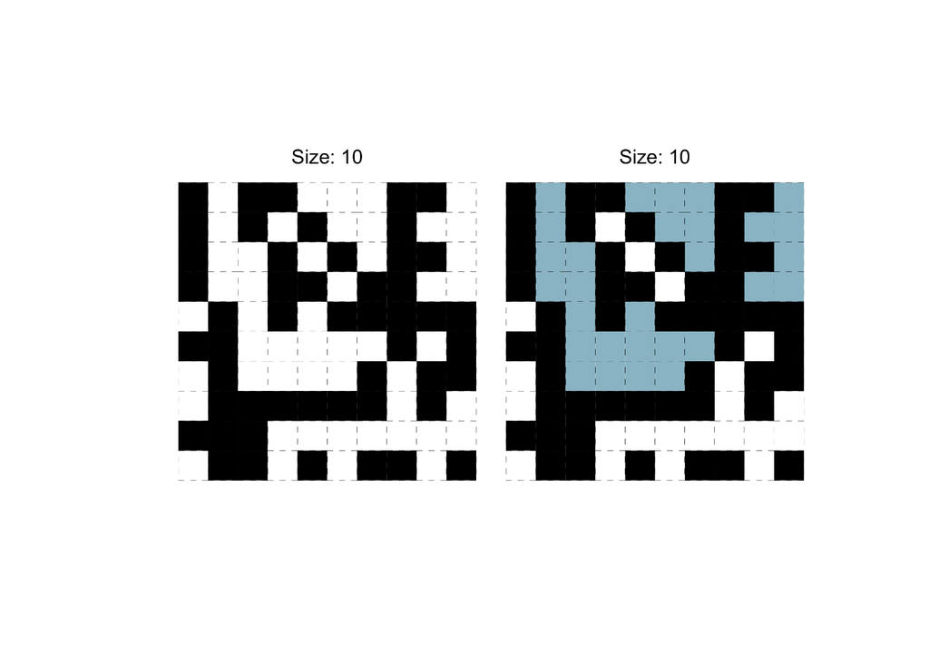

Now imagine we had a way to randomly generate these boards. We would like to see if there are certain types of randomly-generated boards that more likely to percolate. We’ll formalize this task in this homework.

So what are the goals of this homework? We will be developing a package with version control and github connection. This package will encapsulate a set of functions related to a new object, called `board`. While developing our package, we will be writing the following functions: `generate_board_mat()` will generate a random board (matrix version) with white “open” squares and black “blocked” squares. `is_valid()` will check whether or not a given board matrix is correctly formatted. `plot.board()` will plot the board, similar to the four boards shown above. The last two functions contribute the challenges to this homework: `percolate.board()`, which determines whether or not a board percolates, and `read_board()` reads in a text file that specifies many boards. **Note that `plot.board()` and `percolate.board()` will be methods of the class.**

We will not give you explicit guidance on how to debug and test throughout most of this homework, but the concepts and tools you’ve learned in lecture will certainly be beneficial as you write and try out your code.

**Note:** The grading of this homework with depend mainly on whether or not you pass the test cases provided. Your implementation of `percolate.board()` and `read_boards()` might look quite different from another classmates, but be sure that your code passes the tests if you want full credit!

# Making a package and using version control

As you will be learning version control and connection to github during Wednesday’s lecture and making packages but you should start this assignment early in the week, I provide 3 ways to approach this homework (conditional on your experience and willingness to read future lectures). *I recommend that you try to at least start with Approach 2 if you have some knowledge about `Github`.*

**Approach 1 (Base Approach):**

Start writing all you code into this homework `.Rmd` file as usual. As long as the code you write well documented the you can transfer your code to a package with version control at the very end (this is less prefered in terms of using version control - but is fine for now). At the very end of the assignment will be guidance on how to create your package with version control. Note: the “Approach 2/3” comments throught this document can also aid this this endeavor.

*In this approach - it is very important that all functions and tests you write deal well with the “local” vs “global” paradigm - that is, don’t assume more things are in the global environment than you need.*

**Approach 2 (Github start):**

Using the guide in Wednesday’s Lecture, create a new github *public* repository please call it `percolate` and create a project in your Rstudio that links to it. Please additionally make folders `R/` and `/tests/testthat/` in this new directory. We will put your functions and class definitions in `.R` files in the `R/` folder and your tests in `.R` files in the `tests/testthat/` folder. I provide a small section at the end of the homework on how you should moving from being “approach 2” to “approach 3”.

**Approach 3 (package start):**

Similar to the **Approach 2**, create a new github *public* repository please call it `percolate` and create a project in your Rstudio that links to it. Using `usethis::create_package("percolate")` create a package in this directory. Make sure in your console you call this function when you are in the folder that contains the folder `precolate`.

To navigate in the console use `setwd()` and `getwd()` (which sets the directory you’re in and returns which directory you’re currently in)

You will be using `usethis` to set up your package and `devtools` to check your tests, document your functions and more. **Please also see closing remarks at the bottom of the file.**

# Generating and plotting boards

In the first section, we will be creating our new class `board` as well as helper function and a plot function for our object. We will write `generate_board_mat()`, and create a class object that can either take in a matrix or generate the board with certain parameters. In this section we will also create the function `is_valid()` and the method `plot.board()`. To no surprise, we can represent these boards as square, numeric matrices with dimension `n` by `n`. These matrices will only have values `0` (for black “blocked” squares), `1` (for white “open and dry” squares), and `2` (for blue “open and flooded”) squares.

**Approach 2:** you’ll see the names of files to create / update. Just run the code in these files into your console to get interactions.

**1a.** Before we define our class let’s define a helper funtion to generate boards. Write the function `generate_board_mat()` that takes arguments `n` (a positive integer denote the size of the board) and `p` (a number between 0 and 1 that denotes the fraction of the `n^2` squares are blocked). This function should return a `n` by `n` matrix with values `0` or `1`. The specific locations are the `floor(p*n^2)` blocked squares are chosen uniformly at random. Be sure to write lines to check that the input arguments are valid using `assert_that()`. Set the default values to be `n=5` and `p=0.25`. Print the matrix for `generate_board_mat()` (using the default parameters) and `generate_board_mat(n = 8, p = 0.75)`. *Document the function using `Roxygen2` (control + alt + shift + R).*

```r
library(assertthat)
library(testthat)
library(percolate)
```

**Approach 3:** To make sure you have a `tests/testthat` folder, run the commands in the console below while you’re in your package:

```r
usethis::use_testthat()
# and
usethis::use_package("assertthat")
```

**Approach 2/3:** Write this function `generate_board_mat` in a `.R` file called `utils.R` in the `R` folder. Put the suggested examples in the examples section (make sure to run them after your run your function in the console). *For **approach 3** you can create the file using `usethis::use_r("utils")`. and after you’re done writing the function use `devtools::document()` to document the function. Then use `devtools::load_all()` to put the `generate_board_mat` into your working space (you should use this function whenever you update a function or documentation - but I won’t keep mentioning it).*

Finally, add the `utils.R` file (and potentially other files associated with it) and make a commit.

**1b.** Now, using the `test_that()` function, write the following tests: 1) ensure that when using `generate_board_mat()` (default parameters), the output is a `5` by `5` numeric matrix containing only `0` and `1`, 2) ensure the same but for a different value of `n`, 3) ensure that using `p = 0` gives a board with all `1`’s, 4) ensure that using `p=1` gives a board with all `0`’s, 5) ensure that the function throws an error when `n = c(1,2)` or `n="asdf"` or `n = 5.4` or `n = -5`.

**Approaches 2/3:** Write these tests in a `.R` file called `test-utils.R` in the `tests/testthat/` folder. Run your tests and make sure the pass. *For **approach 3**, use `usethis::use_test("utils.R")` to create the `test-utils.R` file in `tests/testthat/`, once written, save file and run `devtools::test()` and see that all your tests have passed.*

Finally, add the `test-utils.R` file (and potentially other files associated with it) and make a commit.

**1c.** One last helper function before our class definition… Now we will write the `is_valid()` function (please document). This function should take in a matrix `mat` as input. It should check that `mat` is a square matrix that contains values only `0`, `1`, or `2` using `assert_that()`. Then, it should return `TRUE`. Hence, `is_valid()` will always throw an error or return `TRUE`. Print out the result of `is_valid(generate_board_mat())` and `is_valid(generate_board_mat(n=1))` (which should both return `TRUE`). Then, write 3 tests using `test_that()` to ensure that `is_valid()` will throw an error for inputs `mat` that are not valid. Each of your 3 tests should be testing for a different reason for invalidity.

**Approaches 2/3:** Place this function into `utils.R` and the associated tests in `test-utils.R`. *For **approach 3**, create documentation and check your tests using the correct `devtools` functions. Remember to do `devtools::load_all()` when done.*

Finally, (sensing a pattern), add updated files and make a commit.

**1d.** Finally! Let’s make a function that returns an object with class `board` (specifically, but have the object also inherit the `matrix` class functionality – aka have `board` be a subclass of `matrix`). This function should **either** take in a matrix (default `= NULL`) or take in and `n` and `p` value (defaults same as `generate_board`). Note: These comments means I want the parameter to be `mat = NULL, n = 5, p = .25`. Additionally, if a matrix (`mat`) is provided (aka non-NULL) then use that at the matrix and create a object of class board. Additionally, add attributes `n` and `p` to the object (empirical values for `p` if `mat` is provided or the generating parameters if not). Write a test to check that if you input a `mat` it returns a `board` with the same structure (use `expect_equivalent` and `unclass` here), and that the empirical `n` and `p` values are correct. Also check if you put in an incorrect matrix structure (check the same matrices in **1c**) it errors. And finally, test some examples of inputting `n` and `p`. *Document your function.*

**Approaches 2/3:** Place this function/class definition into `board.R` and the associated tests in `test-board.R`. Continue following similar procedures for `devtools` calls (**approach 3**) and commits (everyone).

**1e.** Lastly, we will write the `plot.board()` **method**, which also takes in a board `x`. This function should check that `x` is valid using the `is_valid()` function prior to plotting (just in case someone is trying to trick us to plot a fake board). Using `ggplot` (remember back to `my_volcano`) Plot the board so the resulting plot is a square with no axes labels or legend (`+ theme(legend.position = "none")`), has a title stating the size of the board, and has a black square for each `0` entry of `mat`, a white square for each `1` entry of `mat`, and a light blue square for each `2` entry of `mat`. Additionally make the theme `+ theme_void()`. (Hint: It might be desirable to define `n <- attr(board, "n")` before you do anything else. Also, please use the color `lightblue3` when making the image for the light blue squares. You’ll find the `+ scale_fill_manual()` function quite useful… **use a named vector for the `values` in this function.**)

*As always: document, document, document.*

For example, we provide a specific board below, `board_example`. The desired plot you should produce when running `plot(board_example)` is also shown below. Plot your output for `plot(board_example)`. We also provide `board_example2-4` that you should check (but no need to put in documentation or this document).

**Challenge:** make the axis proportional like our examples and have the title centered.

```r
board_example <- board(matrix(c(0,1,1,1,0,
                                0,1,1,0,1,
                                0,0,1,0,0,
                                0,0,0,2,2,
                                2,2,2,2,0), 5, 5))
#^note the matrix will be the transpose of what you see here (due to byrow = F)

board_example2 <- board(matrix(c(0,1,1,1,0,
                                 0,1,1,0,1,
                                 0,0,1,0,0,
                                 0,0,0,1,1,
                                 1,1,1,1,0), 5, 5))

board_example3 <- board(matrix(c(0,2,2,2,0,
                                 0,2,2,0,2,
                                 0,0,2,0,0,
                                 0,0,0,2,2,
                                 2,2,2,2,0), 5, 5))

board_example4 <- board(    # board of size 10 (correctly percolated)
  matrix(c(2, 0, 0, 2, 0, 0, 2, 2, 0, 0,
           2, 2, 2, 0, 0, 2, 2, 0, 0, 1,
           0, 2, 0, 0, 0, 0, 2, 0, 0, 0,
           0, 2, 2, 2, 0, 0, 0, 0, 0, 0,
           0, 2, 0, 0, 0, 0, 1, 0, 0, 0,
           2, 2, 2, 0, 1, 0, 0, 1, 1, 1,
           0, 2, 2, 0, 1, 1, 0, 0, 1, 0,
           1, 0, 2, 0, 0, 0, 0, 1, 1, 0,
           1, 0, 0, 1, 1, 0, 0, 0, 0, 0,
           0, 1, 1, 0, 0, 1, 0, 1, 0, 0),
         10, 10))
```

**Approaches 2/3:** Place this function/class definition into `visualize.R` (tests are hard for visualizations - we’ll ignore them for now - but do put your board_examples in the documentation). Continue following similar procedures for `devtools` calls (**approach 3**) and commits (everyone). * **Approach 3,** since you’re also using a new package add `ggplot2` to the used packages (see how you added `assertthat` at the begining of this problem).*

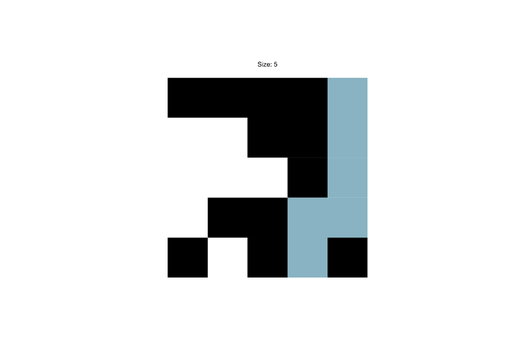

**1f.** *Challenge/Extra*: Add an parameter to `plot.board()` called `grid` which is a boolean. If `grid = FALSE`, nothing additional happens. However, if `grid = TRUE`,draw *dashed* grid lines onto the plot as well, so each square of `mat` is outlined. This is a pretty similar update, but you’ll need to tinker around with it (Hint: look at `geom_tile`) The desired plot when running `plot.board(board_example, grid = TRUE)` is shown below. Plot your output for `plot.board(board_example, grid = TRUE)`.

**Approach 2/3**: update your function, documentation, etc and follow standard git/ devtools approach.

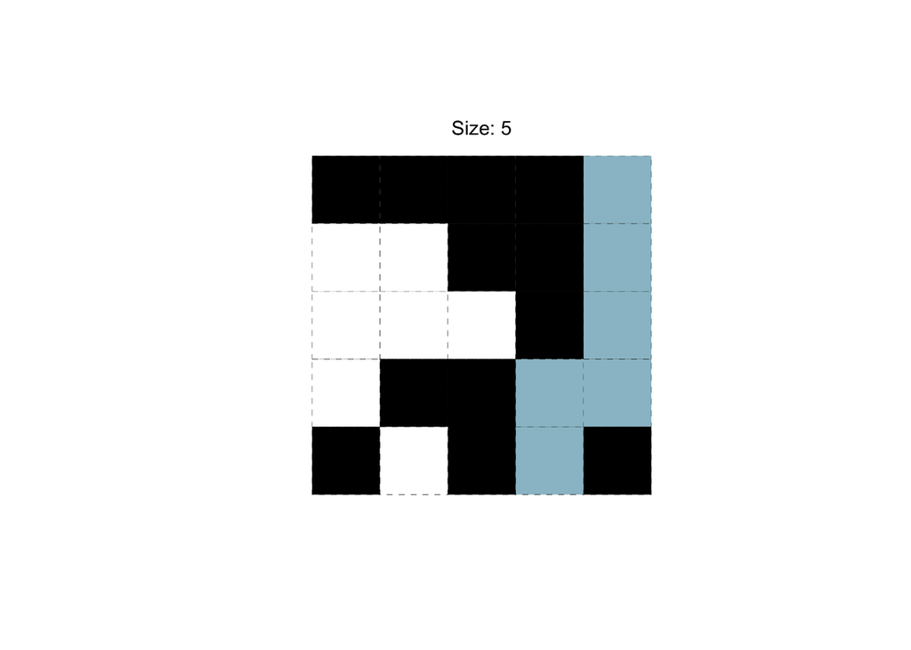

**1g.** Before you go any future, write a few sentences are why it was useful / why you think it will be use to have the `board`’s superclass be `matrix`. (If you have the general idea you can write this after you do the next question.). If you are having struggles thinking about why it’s useful, try doing `t(board_example)` and `board_example[1,2]`.

```
It is useful to have board's superclass be matrix because it will be useful to be able to perform matrix
operations on board objects. I can see how it could be useful to use matrix operations to select certain
rows/columns of the board in later tasks, for example.
```

# Percolating the board

We will now write the `percolate.board()` **method** that takes as input `start_board` (a board) and outputs a list with two entries: `result_board`, the resulting matrix after “water has been poured”, and `result`, a boolean on whether or not `mat` percolates. The function should use the `is_valid()` function to check that `board` is a valid matrix first, and then use a separate call to `assert_that()` to ensure `board` contains only `0`’s and `1`’s.

When computing `result_board`, any open & dry square (i.e, value of `1`) in the top row of `mat` are changed to open & flooded (i.e, changed to a value of `2`). When done, `result_board` should have the same exact pattern of blocked squares (i.e., value of `0`) as `start_board`. In addition, any open & dry square that is adjacent to any open & flooded square becomes open & flooded (via left, right, top and bottom). Once no open & dry square can become open & flooded, your algorithm is done computing `result_board`. To determine whether or not `start_board` percolates, check to see if there are any open & flooded square along the bottom row of `result_board`.

**Important: This is not a course about algorithms. You do not need to write an efficient algorithm, but it needs to be correct. Feel free to use any strategy for this algorithm, even if it’s computationally inefficient.**

- **2a.** Write the **method** `percolate.board()` according to the specifications above. That is, we will be calling the function `percolate` on a `board` object. For consistency, have `percolate` take in `x` and `...` as parameters (and `percolate.board` take in `x`).

We provide 3 example matrices in `mat_example_list` below (before continuing, create a `board_example_list` using `lapply`). Display the boolean results when applying `percolate()` on each board. (You shoult not print the matrices themselves.) Then, using `plot()`, plot 6 boards, (2 rows and 3 columns using `arrange.grid()`) where the top row shows the initial boards in `board_example_list` (from left to right) and the bottom row shows the resulting boards after pouring water. The first two boards should percolate, whereas the last board should not.

**Approach 2/3**: please make a new `.R` file in the `R/` folder (name it `percolate.R`). Follow structure as see in problem 1 in terms of `devtools` and github. Make sure the requested examples are in the example documentation requested.

```r
mat_example_list <- list(matrix(c(1,1,1,1,0,
                                  0,0,0,1,0,
                                  1,1,1,1,0,
                                  0,1,0,0,0,
                                  0,1,1,1,1), 5, 5),
                        matrix(c(1,1,1,1,0,
                                 0,0,0,1,0,
                                 0,1,1,1,0,
                                 0,1,0,0,0,
                                 0,1,1,1,1), 5, 5),
                        matrix(c(1,1,1,1,0,
                                 0,0,0,1,0,
                                 0,1,1,0,0,
                                 0,1,0,0,0,
                                 0,1,1,1,1), 5, 5))
```

**2b.** Now, write four tests to ensure `percolate()` behaves properly. Let `my_board` be a `10` by `10` matrix. The first test should set the input `my_board` as a matrix with all open sites (i.e, all 1’s). The second test should set `my_board` as a matrix with all blocked sites (i.e, all 0’s). The third test should set `my_board` as any valid matrix but have all the squares on the top row be blocked. The last set should set `my_board` as any valid matrix but have all the squares on the bottom row be blocked. You want to ensure that `percolate()` outputs a list (containing `result_board` and `result`) in each of the four tests, gives the correct `result_board` (to the best of your knowledge), and only the first matrix percolates.

**Approach 2/3**: Reminder: this will need a new test file.

**2c.** Fortunately, since this is a class where the TAs can write their own version of `percolate.board()`, we can provide you test cases and their corresponding correct answers. This are provided in https://raw.githubusercontent.com/benjaminleroy/36-350-summer-data/master/Week5/percolate_test.Rdata, which loads in objects `board_list` and `result_list`. Run the following code, which runs your version of `percolate.board()` on 50 different boards (be sure to remove `eval = F` in the code chunk). This `test_that()` function makes sure that your output matches exactly the output our TAs provided. For this question, your code should run and report nothing (as there should be no errors). If there are, go back to your `percolate.board()` function in Q2a and debug your code.

**Approaches 2/3**: put this test in the correct file (and do appriate next steps)

```r
test_that("percolate.board() works with all the test cases",{
  load(url("https://raw.githubusercontent.com/benjaminleroy/36-350-summer-data/master/Week5/percolate_test.Rdata"))

  your_result_list <- lapply(board_list, percolate)

  bool_vec <- sapply(1:length(result_list), function(x){
    your_board <- your_result_list[[x]]$result_board
    result_board <- result_list[[x]]$result_board

    identical(your_board, result_board) *
      (your_result_list[[x]]$result == result_list[[x]]$result)
  })

  expect_true(all(bool_vec))
})
```

You may (optionally) add additional test cases to this question (Q2c) to test specific boards that we provided in `board_list` or boards of your own. This is to your own benefit to do so since you want to have some sort of guarantee that as you “fix” your code, old bugs that have been “dealt with” do not “reappear”.

# Running experiments

**3a.** Hopefully now, your `percolate.board()` function is bug-free! The time `percolate.board()` takes to complete scales with `n` and `p`, the size of the board and the percentage of blocked squares. We can time our algorithm using the `system.time()` function. For example, if we wanted to know how fast our algorithm can perform matrix multiplication, we can compute the following.

```r
n <- 500
system.time(matrix(rnorm(n^2), n, n) %*% matrix(rnorm(n^2), n, n))
```

```
##    user  system elapsed
##    0.16    0.00    0.15
```

The `elapsed` number is the total time that has passed. We can extract this number in the following way. (This number might be slightly different from above since we’re running two separate instances of matrix multiplication.)

```r
system.time(matrix(rnorm(n^2), n, n) %*% matrix(rnorm(n^2), n, n))[3]
```

```
## elapsed
##    0.15
```

For `p = 0.4`, run 10 trials for each value of `n` from `10` to `100` with spacing of `10`. For each trial, generate a random board using `board(...)`. Then, record the elapsed time to compute whether or not the board percolates using `percolate()`. That is, there will be a total of `10*10 = 100` times `percolate()` will be called. After all the trials are completed, compute average elapsed time for each `n`. (Hint: Writing this set of simulations as an `sapply()` might make your life easier.) (Note: This function might take a while to run, so it’s highly encouraged to fully debug your code beforehand and use coding practices you learned Week 5 when doing this.)

Then, make a line plot of elapsed time verses `n^2`. Label your plot appropriately. After inspecting your graph, does it seem like your algorithm’s elapsed time (often called the complexity of the algorithm) linear with `n^2`? (For students more comfortable with CS theory: you can try other values of `n` and change your x-axis to other terms such as `n^2*log(n)` if needed.)

```r
library(tidyverse)
```

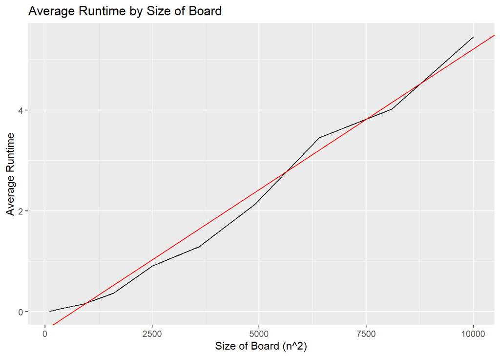

[output not shown]

```r
test_n <- seq(10, 100, by=10)

perc_time_avg <- function(n, p=0.4, trials=10){
  times <- vector()
  for (i in 1:trials){
    my_board <- board(generate_board_mat(n=n, p=p))
    trial_time <- system.time(percolate(my_board))[3]
    times <- c(times, trial_time)
  }
  return(mean(times))
}

avg_times <- sapply(test_n, FUN=perc_time_avg)
time_df <- data.frame(size=test_n^2, avg_time=avg_times)

time_lm <- lm(avg_time ~ size, data=time_df)

ggplot(data=time_df, aes(x=size, y=avg_time)) +
  geom_line() +
  labs(title="Average Runtime by Size of Board", x="Size of Board (n^2)", y="Average Runtime") +
  geom_abline(color="red", slope=coef(time_lm)["size"], intercept=coef(time_lm)["(Intercept)"])
```

**Approach 2/3:** save your homework file in whatever directory you’d like.

**Approach 2:** remove the `eval = F` in the following code and replace the `...` with the path to your project (do global path for be safe). Make this string of the directory contains a “/” at the end of it. This should load all your functions in (I’m assuming your haven’t been putting your code in 2 places).

```r
source("https://raw.githubusercontent.com/benjaminleroy/36-350-summer-data/master/Week5/load_my_files_function.R")
load_my_files("C:/Users/david/OneDrive/Documents/CMU/2019 Summer/36350/percolate/")
```

**Approach 3:** remove the `eval = F` in the following code and replace the `...` with the path to your project (do global path for be safe).

```r
devtools::load_all(path = ...)
```

**3b.** Add a red linear regression line to the plot above (regressing elapsed time onto `n^2`). (no `se` band.)

This challenge problem is for the CS-savy students. The trick is to use efficient data structures that allow faster computation compared to the matrix. If you want a hint on what to code, you can read about the *union/find* data structure in this [this paper](https://arxiv.org/pdf/cond-mat/0101295.pdf) for inspiration. Alternatively, you might find the `igraph` R package to be useful…

**Approach 2/3:** make sure to reload your functions after you make the update.

**3c.** We now want to see how the fraction of blocked sites `p` affects whether or not a board is likely to percolate. For `n = 5`, `n = 10` and `n = 25`, run 20 trials of each value of `p` from `0` to `1` with spacing of `0.05` (i.e, 21 different values of `p`). For each trial, generate a board using `board(...)` and determine if it percolates using `percolate()`. Among the 20 trials for each setting of `n` and `p`, record the percentage of boards that percolated.

That is, there will be a total of `20*21*3 = 1260` times `percolate()` will be called.

Then plot 3 curves (one for each setting of `n`), all on the same plot, of percentage of boards that percolated verses the value of `p` (using only a single data.frame - think back to `dplyr` and `tidyr`). The curves should be a black line for `n = 5`, red for `n = 10` and blue for `n = 25`. Add appropriate axes labels and a legend.

```r
test_p <- seq(0, 1, by=0.05)

perc_percentage <- function(n, p, trials=20){
  successes <- 0
  for (i in 1:trials){
    my_board <- board(generate_board_mat(n=n, p=p))
    if (percolate(my_board)$result){
      successes <- successes + 1
    }
  }
  return(successes/trials)
}

n_5_percentage <- sapply(test_p, FUN=perc_percentage, n=5)
n_10_percentage <- sapply(test_p, FUN=perc_percentage, n=10)
n_25_percentage <- sapply(test_p, FUN=perc_percentage, n=25)
percentage_df <- data.frame(p=test_p, n5=n_5_percentage, n10=n_10_percentage, n25=n_25_percentage) %>%
  gather(key = "size", value = "percentage", 2:4) %>%
  mutate(size=factor(size, levels=unique(.$size)))
```

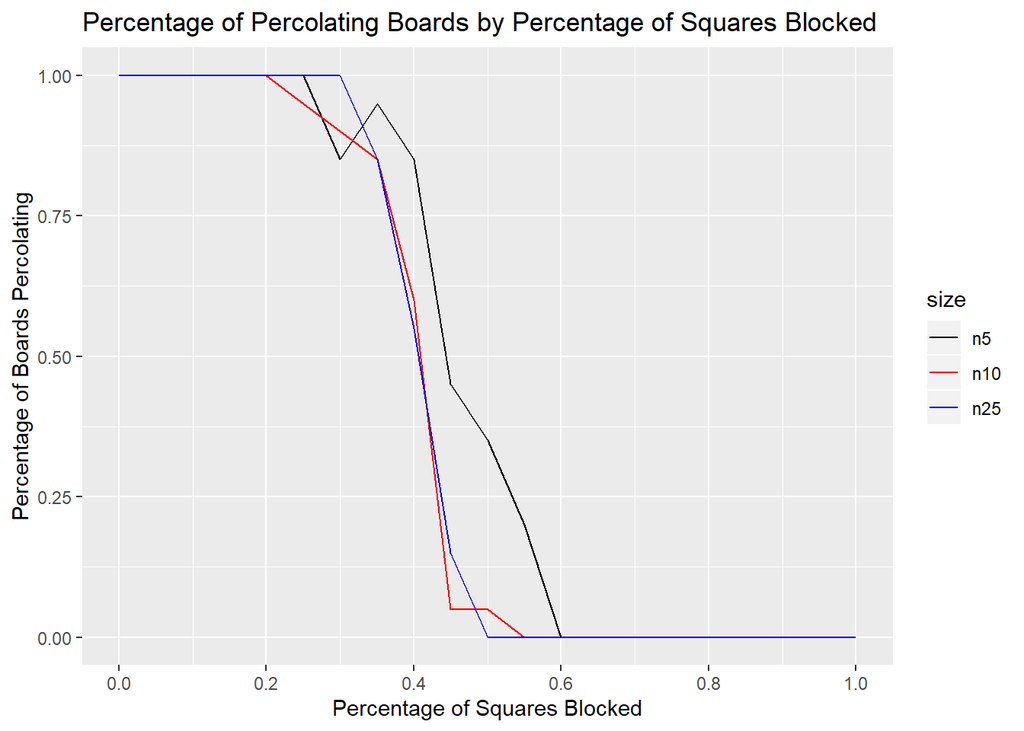

```r
ggplot(data=percentage_df, aes(x=p, y=percentage, color=size)) +
  geom_line() +
  scale_fill_manual(values=c("blue", "red", "black")) +
  labs(title="Percentage of Percolating Boards by Percentage of Squares Blocked",
       x="Percentage of Squares Blocked",
       y="Percentage of Boards Percolating") +
  scale_color_manual(values=c("black", "red", "blue")) +
  scale_x_continuous(breaks=seq(0, 1, by=0.2))
```

After inspecting your graph, do you notice a “phase transition” effect where a small change in `p` results in a large change in the probability of percolation? Roughly what value of `p` do you estimate this value to be, and how do you think it relates to `n`?

```
There seems to be a 'phase transition' around p=0.4. I'm not sure of the relationship
between the phase transition and n, but it seems tobe a steeper phase transition for
larger values of n from my plot.
```

# Reading in boards

In this final section, we will write `read_boards()`, a function that takes in a filepath to a text file and outputs a list of matrices that the text file represents. We describe the specific format of how `read_boards()` should work. Let `file` denote the text file that contains our boards. Each board in `file` is separated by exactly `----`, four dashes. There must be `----` before and after each board. If not, `read_boards()` should error, stating that the `file` is not properly formatted. This is the only way `read_boards()` should throw an error. Hence, the length of the returned list is equal to the number of `----` lines in `file` minus one.

The first non-empty line strictly between the two `----` lines must be a positive integer. This number represents `n`, the size of the board. The next `n` lines afterwards then denote the precise pattern of the `n` by `n` board, row-wise. Each line represents a row of the board and should have exactly `n` visible characters, `*` or `.`. The `*` character represents a blocked square, while the `.` character represents a open square. If the lines between the two `----` lines do not meet these specifications, then return an `NA` (for an incorrectly specified board) instead of an `n` by `n` matrix for this particular board.

Other than storing information pertinent to boards, `file` should not contain any other visible characters, but `file` might have extra spaces or extra line breaks.

We provide a small example of what to expect. The file at https://raw.githubusercontent.com/benjaminleroy/36-350-summer-data/master/Week5/percolation_write_example.txt provides 3 boards, the first two of which are correctly specified and the last of which is not. The raw text of this file looks like this:

```
----
4
* . . *
. . * *
. * . .
. . . .
----
5
. . . . .
* . . . *
. . . . *
. * . . *
* * * * .
----
4
. . . .
* . . *
. . a *
. * . .
----
```

The output of `read_boards("https://raw.githubusercontent.com/benjaminleroy/36-350-summer-data/master/Week5/percolation_write_example.txt")` should then be the following:

```
## [[1]]
##      [,1] [,2] [,3] [,4]
## [1,]    0    1    1    0
## [2,]    1    1    0    0
## [3,]    1    0    1    1
## [4,]    1    1    1    1
## attr(,"class")
## [1] "board"  "matrix"
## attr(,"p")
## [1] 0.3125
## attr(,"n")
## [1] 4
##
## [[2]]
##      [,1] [,2] [,3] [,4] [,5]
## [1,]    1    1    1    1    1
## [2,]    0    1    1    1    0
## [3,]    1    1    1    1    0
## [4,]    1    0    1    1    0
## [5,]    0    0    0    0    1
## attr(,"class")
## [1] "board"  "matrix"
## attr(,"p")
## [1] 0.36
## attr(,"n")
## [1] 5
##
## [[3]]
## [1] NA
```

**Approaches 2/3:** put this function in the `utils.R` folder (and tests in the correct location as well) and load in your functions before doing problem **4d**.

**4a.** Write the `read_boards()` function based on the specifications above. Similar to how you did HW1, you will use the `readLines()` function to read in a file. We highly encourage you to write additional functions to help `read_boards()`, as you will make your life easier if you modularize your function (i.e., write simple functions that are easy to understand, and other functions that piece together these simpler functions as opposed to writing one massive function that does everything itself.) Demonstrate your function works by printing the output to `read_boards("https://raw.githubusercontent.com/benjaminleroy/36-350-summer-data/master/Week5/percolation_write_example.txt")`.

**4b.** Using the `read_boards()` function, load in the 50 boards represented in the text file https://raw.githubusercontent.com/benjaminleroy/36-350-summer-data/master/Week5/percolation_write_test.txt. These are the same boards you looked at in Q2c. Write a `test_that()` function to ensure that after reading in these 50 boards, you get the same boards as `boards_list` located in https://raw.githubusercontent.com/benjaminleroy/36-350-summer-data/master/Week5/percolate_test.Rdata. Your test should use the `identical()` function. (Hint: You might run into some problems when you use the `identical()` function. If you’re stuck, you might be interested in `attributes()` - lists all `attr()`s)

- **4c.** We provide 6 test files, https://raw.githubusercontent.com/benjaminleroy/36-350-summer-data/master/Week5/percolation_write_test1.txt through https://raw.githubusercontent.com/benjaminleroy/36-350-summer-data/master/Week5/percolation_write_test6.txt. (You can look at each of these 6 files in your internet browser.) Each of these test files contains a misspecification. Write 6 tests using `test_that()`, each using one of these 6 files, to show that `read_boards()` properly returns a list containing one `NA` when used on any of these files. (Note: Most likely, as in the other questions, you’ll need to go back to change your implementation of `read_boards()` to accommodate these errors.)

**4d.** As the last question, let’s end with a pretty graphic to use all our functions. Read the board (50 by 50) from https://raw.githubusercontent.com/benjaminleroy/36-350-summer-data/master/Week5/percolation_write_large.txt using `read_boards()`. Then, use the percolate the board using `percolate.board()`. Finally, plot the board before percolation and after percolation (similar to the examples in the Introduction) using `plot.board()`. (Hint: You’ll need to use `grid.arrange(...,ncol = 2)`.)

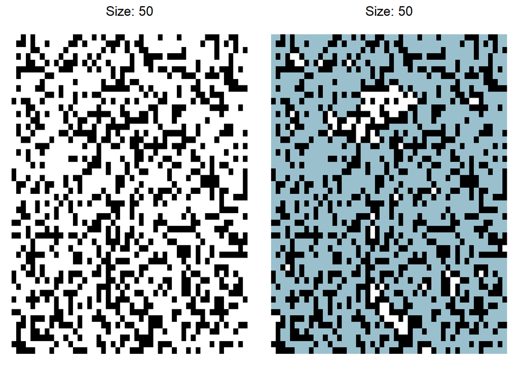

```r
library(gridExtra)
library(rlist)

path <- "https://raw.githubusercontent.com/benjaminleroy/36-350-summer-data/master/Week5/percolation_write_large.txt"
this_board <- read_boards(path)[[1]]
both_boards <- list(original=plot(this_board), new=plot(percolate(this_board)[[1]]))

grid.arrange(grobs=both_boards, ncol=2)
```

# Approach 1: Making a package and using version control

Hi there. Congratulations on completing coding of this assignment! We now need to convert the code in this file into a package. First, please save this file as “hw_5-transfer.Rmd” so if you accidently delete things / things aren’t working you can come back to previous work.

Now, we first need to create a github directory (See notes in Wednesday lecture for a refresher). Create a new github *public* repository please call it `percolate` and create a project in your Rstudio that links to it.

Following Friday’s lecture, we want to make a package in this project. Using `usethis::create_package("percolate")` create a package in this directory. Make sure in your console you call this function when you are in the folder that contains the folder `precolate`.

*To navigate in the console use `setwd()` and `getwd()` (which sets the directory you’re in and returns which directory you’re currently in)*

To set up the package dependencies we’ll be needing today run the following:

```r
usethis::use_testthat()
usethis::use_package("assertthat")
usethis::use_package("ggplot2")
```

Add all the new files you just created and commit them with a good commit message, e.g. “first commit - initalizing package”.

Now, we’ll be transfering tests and functions from this document to your package directory. Use the `usethis::use_r` command we learned in Friday’s lecture to create new R function files and use the `usethis::use_test` command to create new test files (note that `usethis::use_test("banana")` will create a `test-banana.R` file).

**utils.R and test-utils.R**

Run

```r
usethis::use_r("utils")
```

and store *function* code you wrote in 1a, 1c, and problem 4. In your console (with the directory as your package directory), run `devtools::document()`, then run `devtools::load_all()` look at `?generate_board_mat` to see that the documentation is done correctly.

Run

```r
usethis::use_test("utils")
```

and store tests of the functions in `utils.R` (found in 1b, 1c and problem 4). Run `devtools::tests()`. If this fails, examine where it fails and correct. After tests are running, add all these new files and commit the files you updated.

**board.R and test-board.R**

Create a new R file named `board.R` (same way you created `utils.R`) and add the function/ class structure defined in 1c. Add associated test to a test files (named `test-board.R`).

Create documentation your function with `devtools::document()`, load your package with `devtools::load_all()`, make sure your tests still run pass with `devtools::test()` (update if they do not.

Add updated/ new files and commit them.

Congrats! Now your code is a package with version control!

**doing problem 3**

Go to problem 3’s start and follow the directions for **Approach 3**. Remove code (feel free to also remove text that I wrote as well), above problem 3 (except for problem 1g). Make sure your homework file still knits.

*Finally*, jump down to the final section of this document labeled **Approach 3** (two sections below).

# Approach 2

Hi there. Congratulations on completing coding of this assignment while using version control! We now need to convert the code in your directory into a package. Before we go any futher, please make sure you commit all files that you’ve changed and want a snapshot of (it will be impossible to correct errors that occur when transfering to a package if you do not.)

Following Friday’s lecture, we want to make a package in this project. Using `usethis::create_package("percolate")` create a package in this directory. Make sure in your console you call this function when you are in the folder that contains the folder `precolate`.

To navigate in the console use `setwd()` and `getwd()` (which sets the directory you’re in and returns which directory you’re currently in)

You’ll probably notice that the function `create_package` notices a lot of structure you already have - make sure you only overwrite things that don’t effect the functionality of your code (for example - you should feel free to overwrite the `.rproj` file, but not any files in `R` and `tests/testthis`)

To set up the package dependencies we’ll be needing today run the following:

```r
usethis::use_testthat()
```

```
## ✔ Setting active project to 'C:/Users/david/OneDrive/Documents/CMU/2019 Summer/36350/percolate'
## ● Call `use_test()` to initialize a basic test file and open it for editing.
```

```r
usethis::use_package("assertthat")
```

```
## ● Refer to functions with `assertthat::fun()`
```

```r
usethis::use_package("ggplot2")
```

```
## ● Refer to functions with `ggplot2::fun()`
```

Now, run `devtools::document()` to document all your functions. Check that they are well documented by doing `devtools::load_all` and then doing things like `?board` (you can also look at the create folder `man/` and see that all the functions you expect to be documented are).

Now, run `devtools::test()` make sure all your tests run. Else go back and correct/ update them.

Congrats! Now your code is a package!

**doing problem 3**

Go to problem 3’s start and follow the directions for **Approach 3**. Remove code (feel free to also remove text that I wrote as well), above problem 3 (except for problem 1f). Make sure your homework file still knits.

*Finally*, jump down to the final section of this document labeled **Approach 3** (the next section).

# Approach 3 / Everyone

Now that you’ve done all the coding, committed all the files you need for the function, etc. We need to do some clean up and push for package to github.

First, open the “DESCRIPTION” file in the main `percolate` folder. Update this with useful information

Now do the following: - `usethis::use_package_doc()`: this adds a small documentation file if people want to question your package name

**Challenge:** If you have a interesting in making this package a “truely” operational package run `devtools::check`. You’ll see (at minimium) that the we need to actually have tell which namespace functions come from (specifically ggplot2, assert_this and test_this) by doing things like `ggplot2::ggplot(ggplot2::aes(...)) + ggplot2::geom_tile(...)`. Additionally if you use a pipe anywhere run the `usethis::use_pipe()` command. You may also need to add additional packages to your dependences and more (Feel free to chat with me after the Homework is turned in if you’d like help with this).

**What should I submit:**

*(You may wish to save this file under a different name before making this update).*

Please remove all text and code except: 1g, 3a, 3c and 4d (including the `devtools::load_all(path = ...)` call).

To finish of the assignment, go to this [google form](https://forms.gle/8KnzHTXfpoCeZq1s5) and provide your name and github repository link (in the requested format).